# What happens to resting BTC orders on HyperLiquid when price moves

## The interim findings, visually (December 2025, discovery half: odd days only)

This notebook is the visual companion of `INTERIM_REPORT.md` (written 2026-09-25 from the six section reports in this folder). It re-draws each main point from the saved tables of the section reports and shows real market examples, **rendered live from the L4 warehouse** (the order-by-order book, replayed), so you can see what each number looks like on the tape.

### How to read this

- **Interim and descriptive.** Every number describes what happened. Most are **hindsight-aligned**: an event was chosen *because* price later did something (a fast move, a level price reached, a breakout that worked). None of it is a test and nothing here is a trading signal. The **pre-registered confirmatory test is still running on the sealed half and may overturn any of it.**
- **Odd days only.** The 16 odd December days are the discovery half. The even days are a sealed lockbox: every cell below that opens a warehouse file goes through an odd-day guard and refuses an even day.
- **Units.** bps = basis points of price. At ~$88–90k, **1 bp ≈ $9** and HL's $1 tick ≈ 0.11 bp.
- **Uncertainty.** `[a–b]` after a number, and the error bars on the charts, are **day-block bootstrap 95% CIs** (whole days resampled 2,000 times). With 8–16 day clusters, treat every CI as rough.
- **Observability class** of each observation (what a trader could have seen live in December 2025):

| Class | Meaning |
| --- | --- |
| **A** | public, in time: `l2Book` (20 levels a side, ~0.54 s), `bbo`, `trades` (with both wallets), Binance |
| **B-addr** | free, per address: `orderUpdates` for up to 10 chosen addresses (~0.4 s), a known address's resting stops via REST |
| **B-L4** | needs a node or a paid vendor: the full order-level book (who owns each level, pulls vs requotes, taker type, the stop book) |
| **C** | not knowable in time: hindsight labels ("the level price later reached", success / failure), identity, intent |

- **Observation / Interpretation** are kept apart. A wallet is an **address**, never a person, a firm or an intent.

### How to read an event card

The cards are drawn by the warehouse's own `plots.py`:

- **Top panel**: the resting book as a heatmap (every $1 price row x time; darker blue = more BTC resting there; bids sit under the black mid line, asks above it). **Markers are trades**: the marker's *shape* is the taker kind (triangle = fired stop, X = liquidation, circle = IOC, square = frontend market order ...), its *colour* the maker that was filled (the window's top three makers in aqua / yellow / green, everyone else gray).
- **Dashes are pulls** (owner cancels not re-posted by the same wallet within 500 ms), sized by BTC: **red = before the first print at that price** (the size left before price got there), **violet = in the same block** as that print (HL runs a block's cancels before its takers: a protocol property, not foresight), **dark gray = after it / never reached**. Light gray `+` marks are large adds.
- **Bottom panel**: per second, fills (dark) and pulls (red) within 10 bps of the mid; asks up, bids down.
- **Right**: the caption box with the window's numbers (move, volume, taker mix, pulls by timing, top makers). Its **move** is the mid from the window's first instant to its last, not the size of the episode in the title: a window that opens before a move and closes 10 s after its extreme (part of the bounce included) usually shows a smaller move than the title. Its pull totals count every pull in view on both sides, timed against the first print *inside the window*, which is a different accounting from the sections' (they count one side, the traversed levels, near the touch).
- Magenta outlines and labelled lines, where present, are added by this notebook to point at the order or level the example is about.

### Contents

1. The data in one picture
2. Findings by question
   - Q1 + Q3: fast moves and thin levels
   - Q2: breakouts from a range
   - Q4: absorption and large displayed orders ("walls")
   - Q5: liquidity-provider wallets
   - Q6: does anything predict the next move at a manual delay?
   - Q7: other patterns
3. The provisional watch-list
4. Tools: render any odd-day moment; public feed vs L4 truth
5. Caveats, and what the confirmatory track tests next

### Setup

Paths, the **odd-day guards**, the plotting style and the event-card machinery. Nothing here reads an even day: `assert_odd_window` checks every hour file a replay can open (a card reads one file either side of its clock hours) before any file is opened. The warehouse's two month-wide outage tables are filtered to odd-day outages as they are read. Each is a single row group, so pyarrow decodes the even-day rows before the filter drops them, but those rows are never used or shown.

```python
import io, itertools, json, os, sys, tempfile, time, warnings
from pathlib import Path

_T_START = time.time()
WT = Path.home() / "Library/Developer/alpha-wt/hl-l4"
if str(WT / "src") not in sys.path:                     # PYTHONPATH is not set inside Jupyter
    sys.path.insert(0, str(WT / "src"))
DERIVED = Path.home() / "Library/Developer/alpha-l4/derived"   # the L4 warehouse
INTERIM = WT / "var/research/hl_l4/interim"                     # the section reports and their tables
FIG = INTERIM / "figures"
RENDER_LIVE = os.environ.get("HL_L4_NB_SKIP_LIVE") != "1"      # dev switch: skip the warehouse replays

import numpy as np
import pandas as pd
import pyarrow.parquet as pq
from alpha.research.hl_l4 import plots as PL        # the event-card grammar (selects the Agg backend)
from alpha.research.hl_l4 import emulate as EM      # the December-2025 public feed, rebuilt from L4
from alpha.research.hl_l4 import bookstate as BS
from alpha.research.hl_l4 import book as BK
from alpha.research.hl_l4.join import file_of
%matplotlib inline
import matplotlib.pyplot as plt
import matplotlib.figure as mfig
from matplotlib.colors import ListedColormap, LogNorm
from matplotlib.lines import Line2D
from matplotlib.patches import FancyArrowPatch, FancyBboxPatch, Patch, Rectangle
from IPython.display import HTML, Image, Markdown, display
from PIL import Image as PILImage

warnings.filterwarnings("ignore", category=RuntimeWarning)
NS = 1_000_000_000

# ---- the hard rule: ODD December days only -------------------------------------------------- #
MONTH_FILES = 31 * 24                                    # hour files 0..743 (file 0 = Dec 1 00h)
ODD_DAYS = [f"202512{d:02d}" for d in range(1, 32, 2)]
ODD_FILES = [f for f in range(MONTH_FILES) if (f // 24) % 2 == 0]   # the hours of Dec 1, 3, 5, ...


def odd_day(day) -> str:
    """11, '11' or '20251211' -> '20251211'. An EVEN day raises: it is the sealed lockbox."""
    s = str(day).strip()
    d = int(s[-2:])
    if not 1 <= d <= 31 or (len(s) == 8 and not s.startswith("202512")):
        raise ValueError(f"{day!r} is not a December 2025 day")
    if d % 2 == 0:
        raise PermissionError(f"Dec {d} is an EVEN day: the sealed lockbox. This notebook never reads it.")
    return f"202512{d:02d}"


def utc(t) -> str:
    return PL.utc(int(t))


def T(s: str) -> int:
    """'2025-12-11 03:10:37.9' (UTC) -> ns since the epoch."""
    return int(pd.Timestamp(s, tz="UTC").value)


def assert_odd_window(t0, t1) -> list[int]:
    """Every warehouse hour file a replay of [t0, t1) can open (one file either side of the window's
    clock hours; the BBO from t0 - 30 s) must belong to an ODD day. Returns those files."""
    files = [f for f in BS.files_between(int(t0) - 30 * NS, int(t1)) if f < MONTH_FILES]
    for f in files:
        day, hr = file_of(f)
        if int(day[-2:]) % 2 == 0:
            raise PermissionError(
                f"the window {utc(t0)} -> {utc(t1)} would open {day} hour {hr:02d}, an EVEN day (the "
                "lockbox). Keep windows between 01:00 and 22:59 UTC of an odd day.")
    return files


def read_gaps_odd(derived: Path = DERIVED) -> list:
    """book.read_gaps restricted to the outages of ODD-day hour files. The odd-day predicate is passed to
    the parquet read, but gaps.parquet and gap_orders.parquet are each ONE row group, so pyarrow decodes
    every row (even-day outage repairs included) before the filter drops them: even-day rows are
    filtered out on read and never used or displayed. No per-day even-day file is opened."""
    g = pq.read_table(derived / "book" / "gaps.parquet", filters=[("file", "in", ODD_FILES)]).to_pylist()
    if not g:
        return []
    od = pq.read_table(derived / "book" / "gap_orders.parquet",
                       filters=[("gap", "in", [int(r["gap"]) for r in g])])
    gcol, act, oid = od["gap"].to_numpy(), od["action"].to_numpy(), od["oid"].to_numpy()
    is_ask = od["is_ask"].to_numpy(zero_copy_only=False)
    out = []
    for r in g:
        m = gcol == r["gap"]
        pm, fm, sm = m & (act == BK.GAP_PURGE), m & (act == BK.GAP_FILL), m & (act == BK.GAP_STALE)
        fill = BK.BookCols(oid[fm], is_ask[fm], od["px"].to_numpy()[fm].astype(np.int32),
                           od["sz"].to_numpy()[fm], od["wallet"].to_numpy()[fm].astype(np.int32),
                           od["prio"].to_numpy()[fm], np.zeros(int(fm.sum()), bool)).sorted()
        out.append(BK.Gap(int(r["gap"]), int(r["file"]), int(r["seq"]), int(r["ts_before"]),
                          int(r["ts_after"]), oid[pm], fill, oid[sm]))
    return out


ODD_GAPS = read_gaps_odd()
EM.read_gaps = read_gaps_odd          # every BookCursor (cards, the emulated l2Book) sees odd-day outages only


def touches_outage(t0, t1) -> bool:
    return EM.outage_overlaps(ODD_GAPS, int(t0), int(t1))


def read_window(stream: str, cols: list[str], t0, t1) -> pd.DataFrame:
    """Rows of an hour-partitioned warehouse stream (tradesx, bbo, events) with t0 <= ts < t1, read
    from odd-day hour files only."""
    parts = []
    for f in assert_odd_window(t0, t1):
        day, hr = file_of(f)
        p = DERIVED / stream / day / f"{hr:02d}.parquet"
        if p.is_file():
            parts.append(pq.read_table(p, columns=cols, filters=[("ts", ">=", int(t0)),
                                                                 ("ts", "<", int(t1))]).to_pandas())
    return pd.concat(parts, ignore_index=True) if parts else pd.DataFrame(columns=cols)


def price_range(t0, t1, include=(), pad_bps=None, pad_frac=0.15):
    """The window's traded + BBO price range in $, widened to include `include` prices and padded
    (by `pad_bps` of the price, else by `pad_frac` of the span, at least $20 of span)."""
    tr = read_window("tradesx", ["ts", "px"], t0, t1)
    bb = read_window("bbo", ["ts", "bid_px", "ask_px"], t0, t1)
    bb = bb[(bb.bid_px > 0) & (bb.ask_px > 0)]
    vals = [v / 10 for v in (tr.px.min(), tr.px.max(), bb.bid_px.min(), bb.ask_px.max()) if pd.notna(v)]
    vals += [float(v) for v in include]
    lo, hi = min(vals), max(vals)
    pad = pad_bps * 1e-4 * (lo + hi) / 2 if pad_bps is not None else pad_frac * max(hi - lo, 20.0)
    return lo - pad, hi + pad
```

```python
# ---- style: one palette for the whole notebook ------------------------------------------------ #
C = dict(fast="#2a78d6", slow="#eb6834",                       # fast moves / slow controls
         pulled="#e34948", same="#4a3aa7", near="#9085e9",     # pulls: before / same block / last blocks
         filled="#2b2b2b", added="#b9b8b2", requoted="#eda100",
         up="#008300", down="#e34948",
         success="#1baf7a", failed="#4a3aa7", sweep="#eda100", test="#b9b8b2",
         ordinary="#898781", random="#c3c2b7",
         ink="#0b0b0b", ink2="#52514e", muted="#898781", grid="#e1e0d9", surface="#fcfcfb",
         hilite="#c21f8a")
plt.rcParams.update({
    "figure.dpi": 110, "figure.facecolor": C["surface"], "axes.facecolor": C["surface"],
    "savefig.facecolor": C["surface"], "font.size": 10.5, "axes.titlesize": 12,
    "axes.titleweight": "bold", "axes.titlelocation": "left", "axes.labelsize": 10.5,
    "axes.labelcolor": C["ink2"], "axes.edgecolor": "#c3c2b7", "axes.spines.top": False,
    "axes.spines.right": False, "axes.grid": True, "grid.color": C["grid"], "grid.linewidth": 0.6,
    "axes.axisbelow": True, "xtick.color": C["ink2"], "ytick.color": C["ink2"],
    "legend.frameon": False, "legend.fontsize": 9.5, "figure.constrained_layout.use": True})


def esc(s: str) -> str:
    """Escape $ for matplotlib (two $ in one label would be typeset as maths)."""
    return str(s).replace("$", r"\$")


def est(x):
    """(estimate, lo, hi) from any of the section JSONs' shapes."""
    if isinstance(x, (list, tuple)):
        if len(x) == 2 and isinstance(x[1], (list, tuple)):
            return float(x[0]), float(x[1][0]), float(x[1][1])
        return float(x[0]), float(x[1]), float(x[2])
    for k in ("est", "ratio", "rate", "median", "mean", "coef", "diff", "stratified_diff"):
        if k in x:
            ci = x.get("ci95") or x.get("stratified_diff_ci95") or (np.nan, np.nan)
            return float(x[k]), float(ci[0]), float(ci[1])
    raise KeyError(f"no estimate among {list(x)}")


def fmt(t, pct=True, d=0, unit=""):
    e, lo, hi = t
    if pct:
        return f"{100 * e:.{d}f}% [{100 * lo:.{d}f}–{100 * hi:.{d}f}]"
    return f"{e:.{d}f}{unit} [{lo:.{d}f}–{hi:.{d}f}]"


def ci_bars(ax, labels, triples, colors, *, scale=100.0, label_fmt="{:.0f}%", xlabel=None,
            xlim=None, ref=None, height=0.62):
    """Horizontal bars with day-block bootstrap CIs and a value label on each bar."""
    e = np.array([t[0] for t in triples], float) * scale
    lo = np.array([t[1] for t in triples], float) * scale
    hi = np.array([t[2] for t in triples], float) * scale
    y = np.arange(len(labels))
    ax.barh(y, e, color=colors, height=height, edgecolor=C["surface"], linewidth=2)
    ok = np.isfinite(lo) & np.isfinite(hi)
    if ok.any():
        ax.errorbar(e[ok], y[ok], xerr=[e[ok] - lo[ok], hi[ok] - e[ok]], fmt="none",
                    ecolor=C["ink"], elinewidth=1.2, capsize=3.5)
    right = np.where(ok, np.maximum(e, hi), e)
    span = (xlim[1] - xlim[0]) if xlim else max(np.nanmax(right), 1e-9)
    for yi, xi, ei in zip(y, right, e):
        ax.text(xi + 0.015 * span, yi, label_fmt.format(ei), va="center", ha="left", color=C["ink"],
                fontsize=9.5)
    ax.set_yticks(y, [esc(s) for s in labels])
    if not ax.yaxis_inverted():                       # panels may share one y axis: invert it once
        ax.invert_yaxis()
    ax.grid(axis="y", visible=False)
    if xlim:
        ax.set_xlim(*xlim)
    if xlabel:
        ax.set_xlabel(esc(xlabel))
    if ref is not None:
        ax.axvline(ref, color=C["ink2"], lw=1, ls="--")
    return ax


def show_png(name: str, width: int = 1000, note: str | None = None):
    """Embed a figure of the section reports (used only where the table behind it is not saved)."""
    display(Image(filename=str(FIG / name), width=width))
    if note:
        display(Markdown(f"*{note}*"))


# ---- event cards: plots.load_card + plots.draw_card, rendered live ---------------------------- #
_TMP = Path(tempfile.mkdtemp(prefix="hl_l4_nb_"))
_N = itertools.count()
N_LIVE = {"cards": 0, "feeds": 0}


class _Overlay:
    """Draw reference lines and outlined orders on a card's price panel right before plots.draw_card
    saves it (plots.py itself is unchanged)."""

    def __init__(self, t0, hlines=(), vlines=(), boxes=(), spans=(), marks=None):
        self.t0, self.hlines, self.vlines, self.boxes = int(t0), hlines, vlines, boxes
        self.spans, self.marks = spans, marks

    def __enter__(self):
        self._orig = mfig.Figure.savefig
        me = self

        def savefig(fig, *a, **k):
            me.draw(fig)
            return me._orig(fig, *a, **k)

        mfig.Figure.savefig = savefig
        return self

    def __exit__(self, *exc):
        mfig.Figure.savefig = self._orig

    def draw(self, fig):
        ax = next(a for a in fig.axes if a.get_ylabel() == "price ($)")
        x0, x1 = ax.get_xlim()
        bb = {"facecolor": C["surface"], "alpha": 0.85, "lw": 0, "pad": 0.6}
        for ta, tb, lbl in self.spans:             # a shaded stretch of time, labelled at the bottom
            xa, xb = max((int(ta) - self.t0) / NS, x0), min((int(tb) - self.t0) / NS, x1)
            ax.axvspan(xa, xb, facecolor=C["ink"], alpha=0.07, lw=0, zorder=4)
            ax.text(xa + 0.004 * (x1 - x0), ax.get_ylim()[0], f" {esc(lbl)} ", va="bottom", ha="left",
                    fontsize=7.5, color=C["ink"], zorder=9, bbox=bb)
        if self.marks is not None:                 # (ts ns, price $, BTC, legend label): magenta rings
            ts, px, btc, lbl = self.marks
            ax.scatter((np.asarray(ts, np.int64) - self.t0) / NS, np.asarray(px, float) + 0.5,
                       s=6 + 70 * np.sqrt(np.asarray(btc, float)), facecolors="none",
                       edgecolors=C["hilite"], linewidths=0.9, alpha=0.9, zorder=9)
            ax.legend(handles=[Line2D([], [], ls="", marker="o", ms=8, mfc="none", mec=C["hilite"], mew=1.3,
                                      label=esc(lbl))], loc="lower right", fontsize=7.5, framealpha=0.9,
                      facecolor=C["surface"], edgecolor=C["grid"])
        for y, lbl, *st in self.hlines:            # a row spans [p, p + $1): marks sit at its centre
            ax.axhline(y + 0.5, color=C["ink"], lw=1.1, ls=st[0] if st else "-", alpha=0.85, zorder=8)
            ax.text(x0 + 0.01 * (x1 - x0), y + 0.5, f" {esc(lbl)} ", va="bottom", ha="left",
                    fontsize=7.5, color=C["ink"], zorder=9, bbox=bb)
        for t, lbl in self.vlines:
            x = (int(t) - self.t0) / NS
            ax.axvline(x, color=C["ink"], lw=0.9, ls=(0, (2, 2)), alpha=0.75, zorder=8)
            ax.text(x, ax.get_ylim()[1], f" {esc(lbl)}", va="top", ha="left", fontsize=7.5,
                    color=C["ink"], rotation=90, zorder=9, bbox=bb)
        for ta, tb, p, lbl in self.boxes:
            xa, xb = (int(ta) - self.t0) / NS, (int(tb) - self.t0) / NS
            xa, xb = max(xa, x0), min(xb, x1)
            ax.add_patch(Rectangle((xa, p - 0.4), max(xb - xa, 0.3), 1.8, fill=False,
                                   ec=C["hilite"], lw=1.8, zorder=10))
            ax.text(xa, p + 1.6, esc(lbl), color=C["hilite"], fontsize=7.5, va="bottom", ha="left",
                    zorder=11, bbox=bb)
```

```python
# the card grammar's exact colours (plots.py: surface, inks, the three maker slots, the pull colours, the
# depth ramp) plus this notebook's outline colour: reserved in every card's palette, so a small categorical
# marker is never remapped to a heatmap blue
_KEEP = ["#fcfcfb", "#0b0b0b", "#52514e", "#898781", "#e1e0d9", "#c3c2b7", "#1baf7a", "#eda100", "#008300",
         "#b9b8b2", "#e34948", "#4a3aa7", "#ffffff", "#c21f8a", "#cde2fb", "#9ec5f4", "#6da7ec", "#3987e5",
         "#256abf", "#184f95", "#0d366b"]


def _png8(path: Path) -> bytes:
    """A card as a 256-colour PNG (~1/3 of the size): 235 colours fitted to the image + the reserved ones."""
    im = PILImage.open(path).convert("RGB")
    k = 256 - len(_KEEP)
    pal = im.quantize(k, method=PILImage.Quantize.MEDIANCUT).getpalette()[: 3 * k]
    pal += [v for h in _KEEP for v in (int(h[1:3], 16), int(h[3:5], 16), int(h[5:7], 16))]
    ref = PILImage.new("P", (1, 1))
    ref.putpalette(pal)
    b = io.BytesIO()
    im.quantize(palette=ref, dither=PILImage.Dither.NONE).save(b, "PNG", optimize=True)
    return b.getvalue()


def render_card(t0, t1, px_lo=None, px_hi=None, *, title=None, hlines=(), vlines=(), boxes=(),
                spans=(), marks=None, caption=None, width=1080, dpi=90):
    """Replay [t0, t1) from the warehouse and draw it as an event card (prices in $, times ns).
    Refuses an even day and a window that touches a data outage. Returns the card's numbers
    (plots.draw_card stats); assign the result (`_ = render_card(...)`) at the end of a cell."""
    t0, t1 = int(t0), int(t1)
    assert_odd_window(t0, t1)
    if touches_outage(t0, t1):
        raise ValueError(f"{utc(t0)} -> {utc(t1)} touches a data outage; the study drops such windows")
    if not RENDER_LIVE:
        display(Markdown(f"*(live card skipped in this run: {utc(t0)} → {utc(t1)} UTC)*"))
        return {}
    lo = None if px_lo is None else int(np.floor(px_lo * 10))
    hi = None if px_hi is None else int(np.ceil(px_hi * 10))
    c = PL.load_card(DERIVED, t0, t1, lo, hi)
    out = _TMP / f"card_{next(_N):03d}.png"
    with plt.rc_context():
        plt.rcdefaults()                                    # the card's own style, not this notebook's
        with _Overlay(t0, hlines, vlines, boxes, spans, marks):
            stats = PL.draw_card(c, out, title=esc(title) if title else None, dpi=dpi)
    display(Image(data=_png8(out), width=width))
    out.unlink(missing_ok=True)
    N_LIVE["cards"] += 1
    if caption:
        display(Markdown(caption.replace("$", r"\$")))
    return stats


def note(obs: str, interp: str, cls: str):
    """The Observation / Interpretation / Class box under each finding."""
    display(Markdown(("**Observation.** " + obs + "\n\n**Interpretation.** " + interp
                      + "\n\n**Class.** " + cls).replace("$", r"\$")))


# ---- the section reports' numbers --------------------------------------------------------------- #
def _j(name):
    return json.loads((INTERIM / f"{name}.json").read_text())


Q13, Q2, Q4, Q5, Q67 = (_j(n) for n in ("q1q3_fast_moves", "q2_breakouts", "q4_absorption",
                                         "q5_wallets", "q6q7_response_patterns"))
SUMMARY = _j("interim_summary")
assert SUMMARY["data"]["even_days_read"] is False
for d in Q2["days_used"] + Q4["days_used"] + Q5["days"]:
    odd_day(d)                                   # every section says: odd days only
print(f"warehouse: {DERIVED}\nodd-day outages known to this notebook: "
      + ", ".join(f"{utc(g.ts_before)[5:16]}–{utc(g.ts_after)[11:16]}" for g in ODD_GAPS)
      + f"\nlive replays: {'ON' if RENDER_LIVE else 'OFF (dev run)'}")
```

```
warehouse: ~/Library/Developer/alpha-l4/derived
odd-day outages known to this notebook: 12-15 12:27–12:47, 12-21 13:39–14:09, 12-21 14:31–15:03
live replays: ON
```

## 1. The data in one picture

The data is the Albers–Cucuringu–Howison–Shestopaloff **"Open Book"** release (Zenodo 18184441): three streams written by a non-validating HyperLiquid node. The warehouse joins them so that every change to the BTC book has a time, an order, a wallet and a cause, and from that it replays the full order-by-order ("L4") book at any instant.

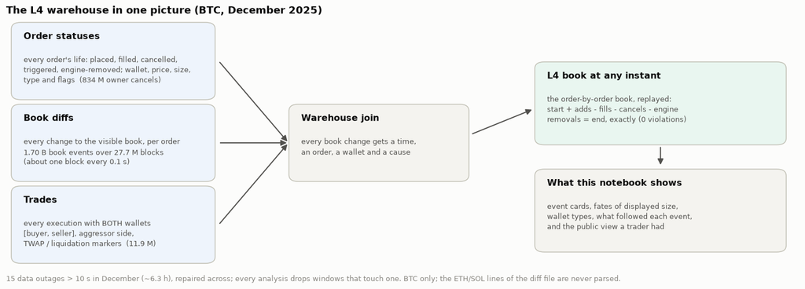

```python
fig, ax = plt.subplots(figsize=(13, 4.6))
ax.set_axis_off()
ax.set_xlim(0, 100)
ax.set_ylim(0, 44)


def box(x, y, w, h, head, body, fc):
    ax.add_patch(FancyBboxPatch((x, y), w, h, boxstyle="round,pad=0.35,rounding_size=1.2", fc=fc,
                                ec="#c3c2b7", lw=1))
    ax.text(x + 1.2, y + h - 1.4, head, weight="bold", va="top", fontsize=10.5, color=C["ink"])
    ax.text(x + 1.2, y + h - 5.4, body, va="top", fontsize=8.8, color=C["ink2"], linespacing=1.35)


def arrow(xy0, xy1):
    ax.add_patch(FancyArrowPatch(xy0, xy1, arrowstyle="-|>", mutation_scale=14, lw=1.3,
                                 color=C["ink2"]))


box(1, 30, 25, 13, "Order statuses", "every order's life: placed, filled, cancelled,\ntriggered, "
    "engine-removed; wallet, price, size,\ntype and flags  (834 M owner cancels)", "#eef4fc")
box(1, 15.5, 25, 13, "Book diffs", "every change to the visible book, per order\n"
    "1.70 B book events over 27.7 M blocks\n(about one block every 0.1 s)", "#eef4fc")
box(1, 1, 25, 13, "Trades", "every execution with BOTH wallets\n[buyer, seller], aggressor side,\n"
    "TWAP / liquidation markers  (11.9 M)", "#eef4fc")
box(36, 15.5, 22, 13, "Warehouse join", "every book change gets a time,\nan order, a wallet "
    "and a cause", "#f4f3ef")
box(67, 22, 31, 14, "L4 book at any instant", "the order-by-order book, replayed:\nstart + adds - fills "
    "- cancels - engine\nremovals = end, exactly (0 violations)", "#e9f6f0")
box(67, 3, 31, 14, "What this notebook shows", "event cards, fates of displayed size,\nwallet types, "
    "what followed each event,\nand the public view a trader had", "#f4f3ef")
for y in (36.5, 22, 7.5):
    arrow((26.8, y), (35.6, 22))
arrow((58.6, 23.5), (66.5, 28))
arrow((82.5, 21.5), (82.5, 17.8))
ax.text(0, -2.5, "15 data outages > 10 s in December (~6.3 h), repaired across; every analysis "
        "drops windows that touch one. BTC only; the ETH/SOL lines of the diff file are never parsed.",
        fontsize=8.5, color=C["muted"])
ax.set_title("The L4 warehouse in one picture (BTC, December 2025)")
plt.show()
```

**The month, and the half this notebook reads.** December 2025 is the one month of the release where all three streams are complete. BTC traded between about $84k and $95k, in a downtrend. Below: hourly BTC closes for the **16 odd days only**; the even days are hatched and were never read.

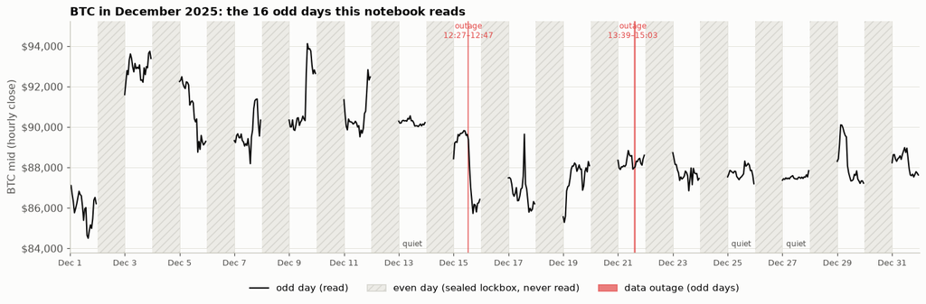

```python
rows = []
for d in ODD_DAYS:                                       # odd days only, each from its own file
    c = pq.read_table(DERIVED / "candles" / "1m" / f"{odd_day(d)}.parquet", columns=["t", "c"]).to_pandas()
    rows.append(c.assign(day=d))
cd = pd.concat(rows, ignore_index=True)
cd["time"] = pd.to_datetime(cd.t, unit="ns", utc=True)
hourly = cd.groupby(["day", cd.time.dt.floor("h")]).c.last().reset_index()

fig, ax = plt.subplots(figsize=(13, 4.2))
for d, g in hourly.groupby("day"):
    ax.plot(g.time, g.c / 10, color=C["ink"], lw=1.4)
d0 = pd.Timestamp("2025-12-01", tz="UTC")
for k in range(1, 31, 2):                                # Dec 2, 4, ..., 30: sealed
    a = d0 + pd.Timedelta(days=k)
    ax.axvspan(a, a + pd.Timedelta(days=1), facecolor="#ecebe6", edgecolor="#d6d5cf", hatch="///", lw=0)
for g in ODD_GAPS:
    a, b = pd.Timestamp(g.ts_before, tz="UTC"), pd.Timestamp(g.ts_after, tz="UTC")
    ax.axvspan(a, b + pd.Timedelta(minutes=20), color=C["pulled"], alpha=0.7, lw=0)
ymax = hourly.c.max() / 10
for day, lbl in (("20251215", "outage\n12:27–12:47"), ("20251221", "outage\n13:39–15:03")):
    ax.annotate(lbl, (pd.Timestamp(day, tz="UTC") + pd.Timedelta(hours=13), ymax + 150), fontsize=8,
                color=C["pulled"], ha="center", va="bottom")
for day in ("20251213", "20251225", "20251227"):
    ax.annotate("quiet", (pd.Timestamp(day, tz="UTC") + pd.Timedelta(hours=12), hourly.c.min() / 10 - 400),
                fontsize=8, color=C["ink2"], ha="center")
ax.set_xlim(d0, d0 + pd.Timedelta(days=31))
ax.set_ylim(hourly.c.min() / 10 - 700, ymax + 1100)
ax.set_xticks([d0 + pd.Timedelta(days=k) for k in range(0, 31, 2)],
              [f"Dec {k + 1}" for k in range(0, 31, 2)], fontsize=8.5)
ax.yaxis.set_major_formatter(lambda v, _: f"${v:,.0f}")
ax.set_ylabel("BTC mid (hourly close)")
ax.legend(handles=[Line2D([], [], color=C["ink"], lw=1.4, label="odd day (read)"),
                   Patch(facecolor="#ecebe6", edgecolor="#d6d5cf", hatch="///", label="even day (sealed lockbox, never read)"),
                   Patch(color=C["pulled"], alpha=0.7, label="data outage (odd days)")],
          loc="upper center", bbox_to_anchor=(0.5, -0.1), ncol=3)
ax.set_title("BTC in December 2025: the 16 odd days this notebook reads")
plt.show()
```

| What | December BTC, this warehouse |
| --- | --- |
| Book events (every change to the visible book) | **1.70 B** over 27.7 M blocks (~one block every 0.1 s) |
| Trades (each with both counterparties' wallets) | **11.9 M** |
| Owner cancels | 834 M |
| Wallet addresses in the dataset's map | 328,456 |
| Data outages > 10 s | **15, about 6.3 h** in total; on the odd days: Dec 15 12:27–12:47 and Dec 21 13:39–15:03 UTC |
| Pull vs requote (a label, not a fact) | 54.5% of cancelled size is "pulled" at Δ = 500 ms, 18.1% at Δ = 2 s. Most sections use 500 ms |

**One fast move, replayed live from the warehouse.** Dec 11, 03:10:47 UTC: BTC fell 35 bps in 34 s. Look at the bid rows below the price that are full (blue) and then turn into **red dashes** at 03:11:11–03:11:22, *before* the black mid line reaches them: that size was cancelled before price got there. Where price did trade, about half the volume came from **fired stops (triangles) and liquidations (X)**.

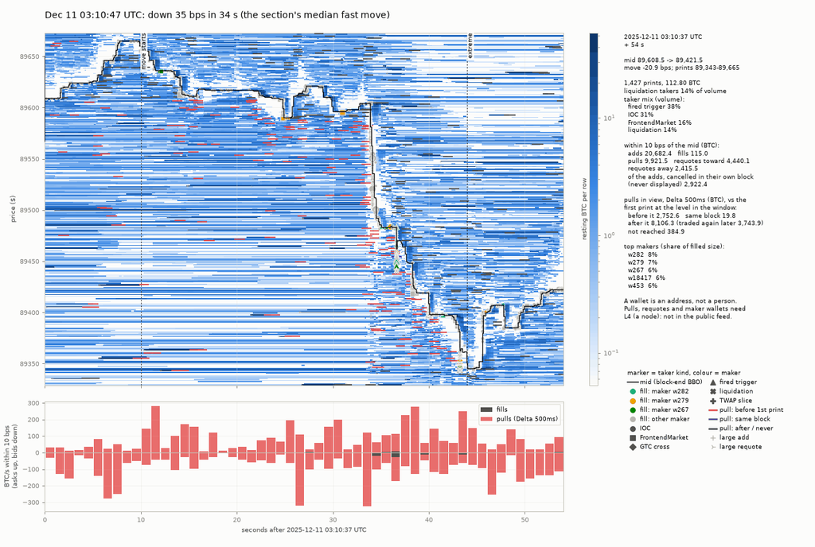

**What to look at:** full bid rows that turn into red dashes seconds before the mid reaches them; of the size pulled within 2 bps of the touch, 95% left early and 68% before the move even started. Of the 77.5 BTC that did fill at traversed levels, 61% came from orders placed within 2 s of the first print at their level. (The caption box's 'move' runs from the window's first instant to its last, 10 s past the extreme and after part of the bounce, so it is smaller than the episode's 35 bps, start to extreme, in the title.)

```python
_ = render_card(T("2025-12-11 03:10:37.9"), T("2025-12-11 03:11:31.9"), 89329, 89672,
                title="Dec 11 03:10:47 UTC: down 35 bps in 34 s (the section's median fast move)",
                vlines=[(T("2025-12-11 03:10:47.9"), "move starts"), (T("2025-12-11 03:11:21.9"), "extreme")],
                caption="**What to look at:** full bid rows that turn into red dashes seconds before the mid "
                        "reaches them; of the size pulled within 2 bps of the touch, 95% left early and 68% "
                        "before the move even started. Of the 77.5 BTC that did fill at traversed levels, 61% "
                        "came from orders placed within 2 s of the first print at their level. (The caption "
                        "box's 'move' runs from the window's first instant to its last, 10 s past the extreme "
                        "and after part of the bounce, so it is smaller than the episode's 35 bps, start to "
                        "extreme, in the title.)")
```

### What a trader could actually see live in December 2025

| Feed | What it showed | Class |
| --- | --- | --- |
| `l2Book` | **20 price levels a side, a snapshot every ~0.54 s.** At $1 grouping that covers only about **$20 (≈ 2 bps)**; coarser grids ($10, $100) reach further but merge levels. Net size per level: no owners, … | **A** |
| `bbo` | best bid and ask on every block where they change | **A** |
| `trades` | price, size, aggressor side and **both wallets of every print** (no taker type, no liquidation flag) | **A** |
| `orderUpdates` | order events for **up to 10 chosen addresses per IP**, ~0.4 s | **B-addr** |
| REST `frontendOpenOrders` | a known address's resting **stop, TP and reduce-only orders before they fire** (≤ 60 requests/min/IP) | **B-addr** |
| a node / paid vendor | the full order-level book of everyone: owners, order ages, pull vs requote, flicker under one snapshot, taker type, the stop book | **B-L4** |

**No public feed showed order-level (L4) data in December 2025.** From cue to order, the fastest pre-armed one-click reaction is ~**0.9 s** (tape or `bbo` cue) and ~**1.2 s** (book cue); the study uses **2 s** as the best-case manual delay and 5 s as typical. Tier-0 fees are 4.5 bps taker and 1.5 bps maker, so **9 bps for a taker round trip**. Section 4 has a tool that draws the emulated public feed next to the L4 truth for any odd-day window.

**Why some things *look* like foresight: HL's in-block ordering rule.**

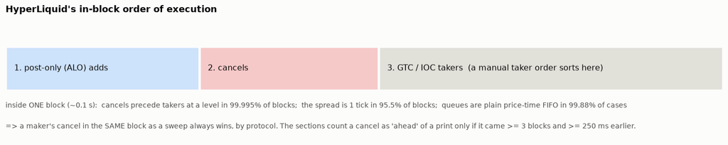

```python
fig, ax = plt.subplots(figsize=(13, 2.5))
ax.set_axis_off()
ax.set_xlim(0, 100)
ax.set_ylim(0, 10)
for x, w, lbl, fc in ((0, 27, "1. post-only (ALO) adds", "#cde2fb"),
                      (27, 25, "2. cancels", "#f6c9c9"),
                      (52, 48, "3. GTC / IOC takers  (a manual taker order sorts here)", "#e1e0d9")):
    ax.add_patch(Rectangle((x, 4), w, 3.6, fc=fc, ec=C["surface"], lw=3))
    ax.text(x + 1.2, 5.8, lbl, va="center", fontsize=10.5, color=C["ink"])
ax.text(0, 2.6, "inside ONE block (~0.1 s):  cancels precede takers at a level in 99.995% of blocks;  "
        "the spread is 1 tick in 95.5% of blocks;  queues are plain price-time FIFO in 99.88% of cases",
        fontsize=9, color=C["ink2"])
ax.text(0, 0.9, "=> a maker's cancel in the SAME block as a sweep always wins, by protocol. The sections "
        "count a cancel as 'ahead' of a print only if it came >= 3 blocks and >= 250 ms earlier.",
        fontsize=9, color=C["ink2"])
ax.set_title("HyperLiquid's in-block order of execution")
plt.show()
```

## 2. Findings by question

### Q1 + Q3: Fast moves and thin levels

**Scope.**

- **88 fast moves**: the 100 ms mid ≥ 20 bps from its trailing 30 s mean; median **38 bps in 31 s**; 51 up, 37 down; from **8 odd days, Dec 1–17** (Dec 13 had none; Dec 19–31 were not used because their per-second aggregates were being rebuilt when this ran).
- **83 slow controls**: the same direction and distance, ≥ 5× slower (median 1,018 s), on 9 days.
- **Traversed levels**: every $1 price the move went through: 33,118 fast and 30,605 slow.

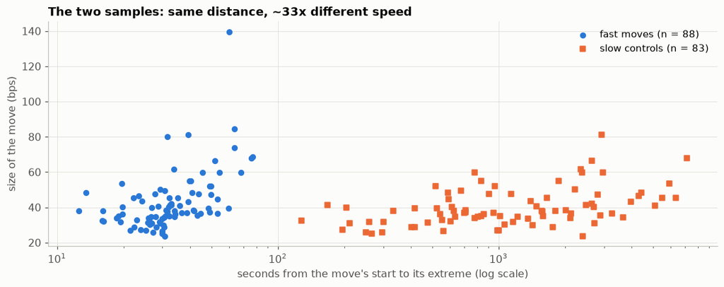

```python
EP = pd.read_parquet(INTERIM / "q1q3_work/episodes.parquet")
EP = EP[(EP.x == 20) & (EP.bad_near == 0)]
for d in EP.day.unique():
    odd_day(d)


def ep_window(ep_id, before=10, after=10, pad=15.0):
    """A fast move's card window, the section's rule: start - 10 s -> extreme + 10 s, mid +- $15."""
    r = EP[EP.ep_id == ep_id].iloc[0]
    lo, hi = min(r.mid_start, r.mid_ext) / 10 - pad, max(r.mid_start, r.mid_ext) / 10 + pad
    return int(r.t_start) - before * NS, int(r.t_ext) + after * NS, lo, hi, r


def near_touch_pulls(ep_id):
    """The Q1 section's OWN pull records for one fast move (q1q3_work/pull_events.parquet, levels.parquet):
    pulls at traversed $1 levels made within 2 bps of the touch at the time (the section's rule,
    dist_bps <= 2), with price ($) and time (ns). tim == 0 = before the first print at that price
    (>= 3 blocks and >= 250 ms). This is the section's accounting, not the card's."""
    odd_day(ep_id[:8])
    flt = [("ep_id", "=", ep_id), ("kind", "=", "fast")]
    pe = pq.read_table(INTERIM / "q1q3_work/pull_events.parquet",
                       columns=["tim", "pull", "dist_bps", "li", "t_rel_start_ms"], filters=flt).to_pandas()
    lv = pq.read_table(INTERIM / "q1q3_work/levels.parquet", columns=["li", "px"], filters=flt).to_pandas()
    r = EP[EP.ep_id == ep_id].iloc[0]
    pe = pe[pe.dist_bps <= 2.0].merge(lv, on="li", how="left")
    return pd.DataFrame({"ts": int(r.t_start) + np.round(pe.t_rel_start_ms.to_numpy() * 1e6).astype(np.int64),
                         "px": pe.px.to_numpy() / 10, "btc": pe.pull.to_numpy() / 1e5,
                         "tim": pe.tim.to_numpy()})


ep = pd.read_parquet(INTERIM / "q1q3_work/episodes.parquet")
ep = ep[(ep.x == 20) & (ep.bad_near == 0)]
sc = pd.read_parquet(INTERIM / "q1q3_work/slow_controls.parquet")
fig, ax = plt.subplots(figsize=(10, 3.9))
ax.scatter(ep.tau_s, ep.D_bps, s=26, color=C["fast"], label=f"fast moves (n = {len(ep)})", zorder=3)
ax.scatter(sc.tau_s, sc.D_bps, s=26, color=C["slow"], marker="s", label=f"slow controls (n = {len(sc)})")
ax.set_xscale("log")
ax.set_xlabel("seconds from the move's start to its extreme (log scale)")
ax.set_ylabel("size of the move (bps)")
ax.legend(loc="upper right")
ax.set_title("The two samples: same distance, ~33x different speed")
plt.show()
```

#### 1.1 Near the touch, most pulled size left well before the first print. In fast moves about half of it left before the move had even started.

Pulled size at traversed levels within 2 bps of the touch (fast: 146,584 pulls / 61,489 BTC; slow: 317,936 / 129,714 BTC), by when it was pulled relative to the **first print at that price**.

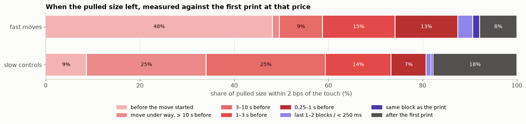

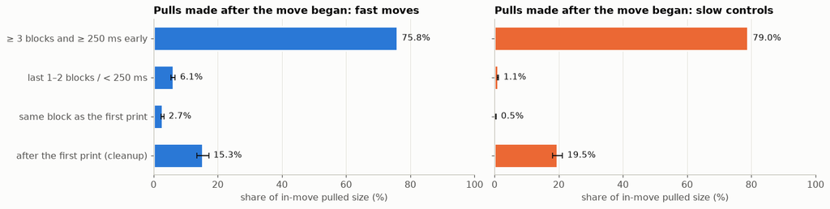

```
The first bar sums four timing buckets, so it carries no CI of its own. Fast 'same block' 2.7% [2.3–3.2] vs slow 0.5% [0.4–0.5].
```

```python
TF, TSL = Q13["timing"]["v2_within2bps_fast"], Q13["timing"]["v2_within2bps_slow"]
B = [("size_pre: before the move started", "before the move started", "#f3b3b2"),
     ("size_pre: move under way, > 10 s before", "move under way, > 10 s before", "#ec8a89"),
     ("size_3-10 s before", "3–10 s before", "#e66b69"),
     ("size_1-3 s before", "1–3 s before", C["pulled"]),
     ("size_0.25-1 s before", "0.25–1 s before", "#b8302f"),
     ("size_1-2 blocks / <250 ms before", "last 1–2 blocks / < 250 ms", C["near"]),
     ("size_same block", "same block as the print", C["same"]),
     ("size_after first print", "after the first print", C["ink2"])]
fig, ax = plt.subplots(figsize=(13, 2.9))
for yi, (lab, src) in enumerate((("fast moves", TF), ("slow controls", TSL))):
    left = 0.0
    for k, name, col in B:
        v = src[k]["est"]
        ax.barh(yi, v * 100, left=left, color=col, edgecolor=C["surface"], lw=1.5, height=0.6)
        if v >= 0.045:
            ax.text(left + v * 50, yi, f"{100 * v:.0f}%", ha="center", va="center", fontsize=9,
                    color="white" if col in (C["pulled"], "#b8302f", C["same"], C["ink2"]) else C["ink"])
        left += v * 100
ax.set_yticks([0, 1], ["fast moves", "slow controls"])
ax.invert_yaxis()
ax.set_xlim(0, 100)
ax.set_xlabel("share of pulled size within 2 bps of the touch (%)")
ax.grid(axis="y", visible=False)
ax.legend(handles=[Patch(color=c, label=n) for _, n, c in B], ncol=4, loc="upper center",
          bbox_to_anchor=(0.5, -0.32), fontsize=9)
ax.set_title("When the pulled size left, measured against the first print at that price")
plt.show()

rows = [("≥ 3 blocks and ≥ 250 ms early", None),
        ("last 1–2 blocks / < 250 ms", "in_move_size_1-2 blocks / <250 ms before"),
        ("same block as the first print", "in_move_size_same block"),
        ("after the first print (cleanup)", "in_move_size_after first print")]
early = ["in_move_size_pre: move under way, > 10 s before", "in_move_size_3-10 s before",
         "in_move_size_1-3 s before", "in_move_size_0.25-1 s before"]
fig, axs = plt.subplots(1, 2, figsize=(13, 3.2), sharey=True)
for ax, (lab, src, col) in zip(axs, (("fast moves", TF, C["fast"]), ("slow controls", TSL, C["slow"]))):
    tri = [(sum(src[k]["est"] for k in early), np.nan, np.nan)] + [est(src[k]) for _, k in rows[1:]]
    ci_bars(ax, [r[0] for r in rows], tri, col, xlim=(0, 100), label_fmt="{:.1f}%",
            xlabel="share of in-move pulled size (%)")
    ax.set_title(f"Pulls made after the move began: {lab}")
plt.show()
print("The first bar sums four timing buckets, so it carries no CI of its own. Fast 'same block' "
      f"{fmt(est(TF['in_move_size_same block']), d=1)} vs slow {fmt(est(TSL['in_move_size_same block']), d=1)}.")
```

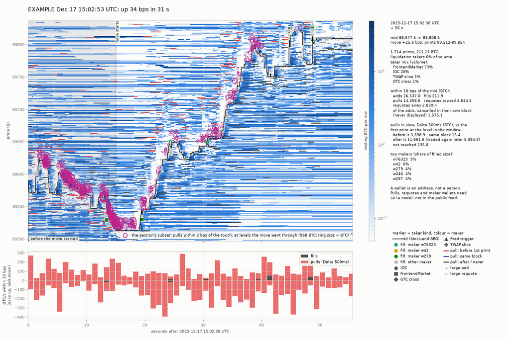

**What to look at:** the card's own red dashes (every pull in view, on both sides, timed against the first print *inside this window*) run along the whole climb, before and after the start, so on their own they do not show the section's point. That point is about the subset ringed in **magenta**: pulls made within 2 bps of the touch at the time, at $1 levels the move later went through (968 BTC). 96% of it left before the first print at its price, but 77% left in the **shaded stretch before the move started**: those rings hug the mid line as it dips to $89,512 just before the climb. They are asks cancelled near the touch as it then stood, at prices the climb later went through: routine quote churn near the old touch, not size leaving ahead of the move.

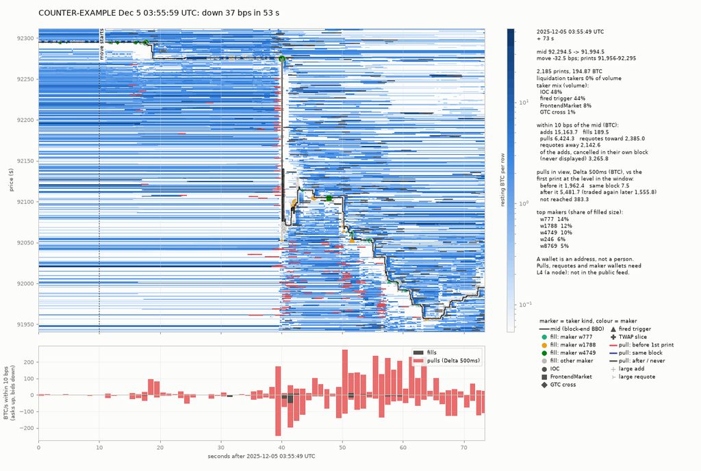

**What to look at:** here the dashes are mostly **dark gray** (after the first print): only 66% was pulled early and just 6% before the start; 27% was pulled after price had already traded there. The book waited to be hit and was cleaned up afterwards.

**Observation.** In fast moves, 87.5% of the pulled size near the touch left ≥ 3 blocks and ≥ 250 ms before the first print at its price, but 48% [46–51] left before the move started. Of the pulls made after the move began: 76% early, 6.1% [5.5–6.8] in the last 1–2 blocks, 2.7% [2.3–3.2] in the same block, 15% [13.5–17.2] after the first print (slow: 79% / 1.1% / 0.5% / 19.5%).

**Interpretation.** Much of 'the liquidity vanished before it was hit' is ordinary churn that happened before anything moved. The in-move pulls are mostly ≥ 250 ms early: anticipation, or a reaction to an earlier cue (a few ticks away, or on another venue: the Binance lead was not tested here). Not a same-block race. Burst-cleanup cancels were not excluded, so every pull share is an upper bound on anything intentional.

**Class.** Pull vs requote, timing and wallet: **B-L4**. A public-feed trader (**A**) sees only the *net* shrinking of a displayed $1 level between ~0.54 s snapshots, within ~2 bps.

```python
E17 = "20251217_x20_541963"                     # the section's example A (a random draw)
t0, t1, lo, hi, r = ep_window(E17, before=15)   # opens 15 s before the start: the whole subset is in view
NP = near_touch_pulls(E17)
tot = NP.btc.sum()
sh_pre = NP.loc[NP.tim == 0, "btc"].sum() / tot
sh_start = NP.loc[(NP.tim == 0) & (NP.ts < int(r.t_start)), "btc"].sum() / tot
ring = (NP.assign(b=(NP.ts - t0) // (NS // 2), row=np.floor(NP.px))      # one ring per 0.5 s x $1 row
          .groupby(["b", "row"], as_index=False).agg(ts=("ts", "min"), btc=("btc", "sum")))
render_card(t0, t1, lo, hi, title="EXAMPLE Dec 17 15:02:53 UTC: up 34 bps in 31 s",
            vlines=[(int(r.t_start), "move starts")],
            spans=[(t0, int(r.t_start), "before the move started")],
            marks=(ring.ts, ring.row, ring.btc,
                   f"the section's subset: pulls within 2 bps of the touch, at levels the move went "
                   f"through ({tot:,.0f} BTC; ring size = BTC)"),
            caption=f"**What to look at:** the card's own red dashes (every pull in view, on both sides, "
                    f"timed against the first print *inside this window*) run along the whole climb, before "
                    f"and after the start, so on their own they do not show the section's point. That point "
                    f"is about the subset ringed in **magenta**: pulls made within 2 bps of the touch at the "
                    f"time, at $1 levels the move later went through ({tot:,.0f} BTC). {100 * sh_pre:.0f}% of "
                    f"it left before the first print at its price, but {100 * sh_start:.0f}% left in the "
                    f"**shaded stretch before the move started**: those rings hug the mid line as it dips to "
                    f"${r.mid_start / 10:,.0f} just before the climb. They are asks cancelled near the touch "
                    f"as it then stood, at prices the climb later went through: routine quote churn near "
                    f"the old touch, not size leaving ahead of the move.")
render_card(T("2025-12-05 03:55:49.0"), T("2025-12-05 03:57:02.4"), 91941, 92311,
            title="COUNTER-EXAMPLE Dec 5 03:55:59 UTC: down 37 bps in 53 s",
            vlines=[(T("2025-12-05 03:55:59"), "move starts")],
            caption="**What to look at:** here the dashes are mostly **dark gray** (after the first print): "
                    "only 66% was pulled early and just 6% before the start; 27% was pulled after price had "
                    "already traded there. The book waited to be hit and was cleaned up afterwards.")
note("In fast moves, 87.5% of the pulled size near the touch left ≥ 3 blocks and ≥ 250 ms before the "
     "first print at its price, but 48% [46–51] left before the move started. Of the pulls made after the "
     "move began: 76% early, 6.1% [5.5–6.8] in the last 1–2 blocks, 2.7% [2.3–3.2] in the same block, "
     "15% [13.5–17.2] after the first print (slow: 79% / 1.1% / 0.5% / 19.5%).",
     "Much of 'the liquidity vanished before it was hit' is ordinary churn that happened before anything "
     "moved. The in-move pulls are mostly ≥ 250 ms early: anticipation, or a reaction to an earlier cue "
     "(a few ticks away, or on another venue: the Binance lead was not tested here). Not a same-block race. "
     "Burst-cleanup cancels were not excluded, so every pull share is an upper bound on anything intentional.",
     "Pull vs requote, timing and wallet: **B-L4**. A public-feed trader (**A**) sees only the *net* "
     "shrinking of a displayed $1 level between ~0.54 s snapshots, within ~2 bps.")
```

#### 1.2 "Pulled faster ahead of a fast move" is a per-second effect of price speed, not more pulling per level

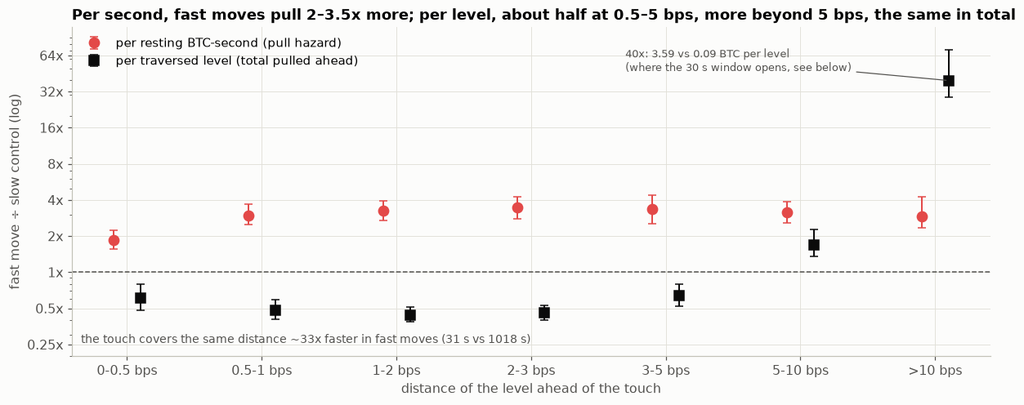

```
> 10 bps, per level: 39.6x [28.9–71.7] (the section prints it as '~40x'), on small amounts: 3.59 BTC (fast) vs 0.09 BTC (slow) per traversed level.
per traversed level, all distances: fast 10.8 vs slow 10.1 BTC, ratio 1.07 [0.92–1.28]
per fast/control pair at 0.5–5 bps (n = 83): median per-level ratio 0.53 [0.50–0.56]; pairs above 1: 7%
```

```python
H = Q13["hazard"]
bands = ["0-0.5", "0.5-1", "1-2", "2-3", "3-5", "5-10", ">10"]
per_s = np.array([est(H[f"ratio_pull_pre_{b}"]) for b in bands])
per_l = np.array([est(H[f"per_level_ratio_{b}"]) for b in bands])
x = np.arange(len(bands))
fig, ax = plt.subplots(figsize=(11, 4.4))
for arr, dx, col, mk, lab in ((per_s, -0.1, C["pulled"], "o", "per resting BTC-second (pull hazard)"),
                              (per_l, 0.1, C["ink"], "s", "per traversed level (total pulled ahead)")):
    ax.errorbar(x + dx, arr[:, 0], yerr=[arr[:, 0] - arr[:, 1], arr[:, 2] - arr[:, 0]], fmt=mk, ms=8,
                color=col, ecolor=col, elinewidth=1.3, capsize=3.5, label=lab)
ax.axhline(1, color=C["ink2"], lw=1, ls="--")
ax.set_yscale("log")
ax.set_yticks([0.25, 0.5, 1, 2, 4, 8, 16, 32, 64], ["0.25x", "0.5x", "1x", "2x", "4x", "8x", "16x", "32x", "64x"])
ax.set_ylim(0.2, 110)
ax.set_xticks(x, [b + " bps" for b in bands])
ax.set_xlabel("distance of the level ahead of the touch")
ax.set_ylabel("fast move ÷ slow control (log)")
ax.legend(loc="upper left")
ts = H["touch_speed"]
ax.text(0.01, 0.04, f"the touch covers the same distance ~{ts['median_time_ratio_slow_over_fast']:.0f}x faster "
        f"in fast moves ({ts['fast_tau_s_median']:.0f} s vs {ts['slow_tau_s_median']:.0f} s)",
        transform=ax.transAxes, fontsize=9, color=C["ink2"])
g10, f10, s10 = per_l[-1], est(H["per_level_fast_>10"])[0], est(H["per_level_slow_>10"])[0]
ax.annotate(f"{g10[0]:.0f}x: {f10:.2f} vs {s10:.2f} BTC per level\n(where the 30 s window opens, see below)",
            (x[-1] + 0.1, g10[0]), xytext=(x[-1] - 2.3, g10[0] * 1.2), fontsize=8.5, color=C["ink2"],
            arrowprops=dict(arrowstyle="-", color=C["ink2"], lw=0.8))
ax.set_title("Per second, fast moves pull 2–3.5x more; per level, about half at 0.5–5 bps, more beyond 5 bps, "
             "the same in total")
plt.show()
print(f"> 10 bps, per level: {fmt(est(H['per_level_ratio_>10']), pct=False, d=1, unit='x')} (the section prints "
      f"it as '~40x'), on small amounts: {f10:.2f} BTC (fast) vs {s10:.2f} BTC (slow) per traversed level.")
PAIR = Q13["extras_v2"]["pairs_0.5-5bps"]
print(f"per traversed level, all distances: fast {est(H['per_level_total_fast'])[0]:.1f} vs slow "
      f"{est(H['per_level_total_slow'])[0]:.1f} BTC, ratio {fmt(est(H['per_level_ratio_total']), pct=False, d=2)}")
print(f"per fast/control pair at 0.5–5 bps (n = {PAIR['n_pairs']}): median per-level ratio "
      f"{fmt(est(PAIR['per_level_ratio_median']), pct=False, d=2)}; pairs above 1: "
      f"{100 * est(PAIR['share_pairs_per_level_ratio_gt1'])[0]:.0f}%")
```

> **What changed after the skeptic review.** The first version's headline "pulled ~3× faster ahead of fast moves" was a *per-second* number. A quoter that keeps a fixed distance from the touch re-prices every time the touch moves, so a faster price means more cancels per second with no anticipation at all. Counted **per traversed level**, fast moves pull about the same in total (ratio 1.07 [0.92–1.28]) and about **half** as much at 0.5–5 bps. The book ahead of a fast move **turns over faster; it is not emptied more per level.**

**The 5 to >10 bps points** are the other side of the same bookkeeping, not a headline: per level, fast moves pull 1.7× more at 5–10 bps and ~40× more beyond 10 bps (3.59 vs 0.09 BTC). Each level's window opens 30 s before price reaches it, and in a fast move a level deep in a 38-bps move is still > 5–10 bps away then, so its pre-arrival pulling is counted out there; a slow move's levels spend almost none of their window that far out. Those bands are where the fast-move windows sit, and they are what brings the total back to ~1× after the deficit close in.

The two examples above show it: Dec 17 15:02:53 had 5.5× its control's per-second hazard but 0.53× per level; Dec 11 03:10:47 had 5.4× per second and 1.03× per level. The counter-example is one of the 6 of 83 pairs where the fast move did pull *more* per level:

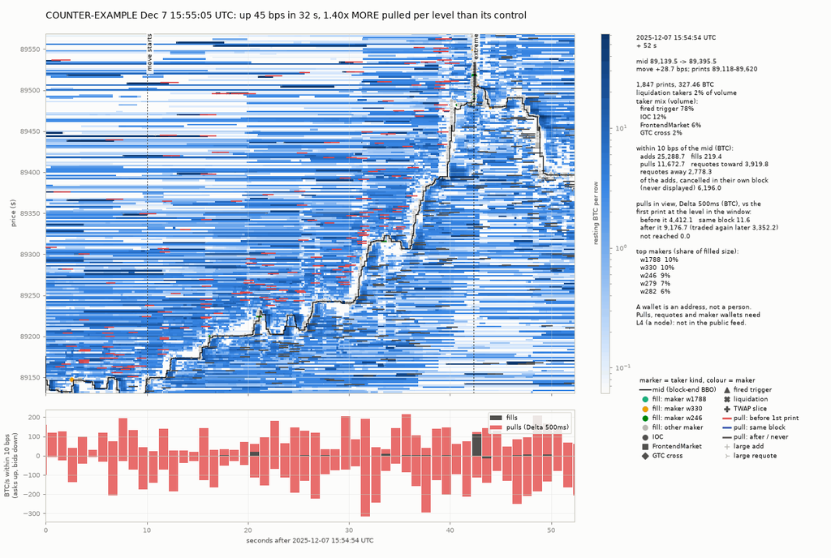

**What to look at:** the red dashes in the asks the mid climbs into (4,412 BTC pulled before the first print at their price, in view). In this move the book really was emptied more per level than in its slow control; it is one of 6 such pairs out of 83.

**Observation.** Per resting BTC-second, fast moves pull 2–3.5x as much as slow ones from 0.5 to > 10 bps ahead (1–2 bps: 3.2x [2.7–3.9]), but the touch covers the distance ~33x faster. Per traversed level the total pulled ahead is the same (10.8 vs 10.1 BTC, ratio 1.07 [0.92–1.28]); at 0.5–5 bps it is about half (83 pairs, median 0.53 [0.50–0.56]; only 7% of pairs above 1).

**Interpretation.** A quoter at a fixed distance re-prices each time the touch moves: faster price, more cancels per second, no anticipation needed. The book ahead turns over faster; it is not emptied more per level.

**Class.** **B-L4**.

```python
t0, t1, lo, hi, r = ep_window("20251207_x20_573347")
render_card(t0, t1, lo, hi,
            title="COUNTER-EXAMPLE Dec 7 15:55:05 UTC: up 45 bps in 32 s, 1.40x MORE pulled per level than its control",
            vlines=[(int(r.t_start), "move starts"), (int(r.t_ext), "extreme")],
            caption="**What to look at:** the red dashes in the asks the mid climbs into (4,412 BTC pulled "
                    "before the first print at their price, in view). In this move the book really was emptied "
                    "more per level than in its slow control; it is one of 6 such pairs out of 83.")
note("Per resting BTC-second, fast moves pull 2–3.5x as much as slow ones from 0.5 to > 10 bps ahead "
     "(1–2 bps: 3.2x [2.7–3.9]), but the touch covers the distance ~33x faster. Per traversed level the "
     "total pulled ahead is the same (10.8 vs 10.1 BTC, ratio 1.07 [0.92–1.28]); at 0.5–5 bps it is about "
     "half (83 pairs, median 0.53 [0.50–0.56]; only 7% of pairs above 1).",
     "A quoter at a fixed distance re-prices each time the touch moves: faster price, more cancels per "
     "second, no anticipation needed. The book ahead turns over faster; it is not emptied more per level.",
     "**B-L4**.")
```

#### 1.3 What trades at a traversed level: mostly fresh quotes from fast wallets, plus whatever slow wallets left resting

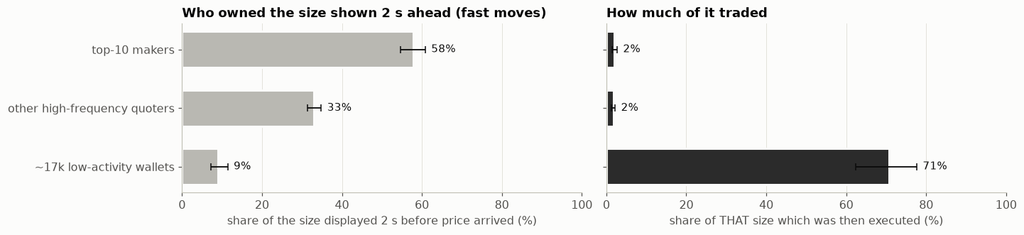

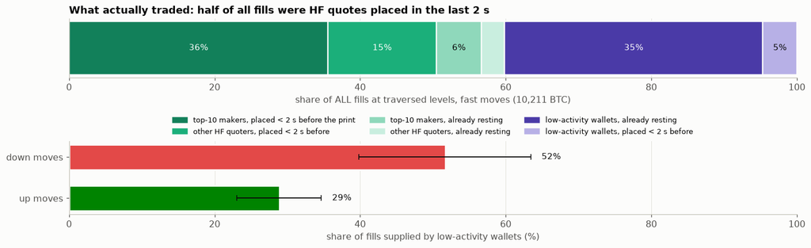

```python
F = Q13["fate"]
types = [("top10", "top-10 makers"), ("hf", "other high-frequency quoters"), ("other", "~17k low-activity wallets")]
fig, axs = plt.subplots(1, 2, figsize=(13, 2.9), sharey=True)
ci_bars(axs[0], [t[1] for t in types], [est(F[f"rest_2s_share_{k}_fast"]) for k, _ in types], C["added"],
        xlim=(0, 100), xlabel="share of the size displayed 2 s before price arrived (%)")
ci_bars(axs[1], [t[1] for t in types], [est(F[f"d2_wtype_{k}_fast"]["filled"]) for k, _ in types],
        C["filled"], xlim=(0, 100), xlabel="share of THAT size which was then executed (%)")
axs[0].set_title("Who owned the size shown 2 s ahead (fast moves)")
axs[1].set_title("How much of it traded")
plt.show()

S = F["allfills_split_fast"]
segs = [("top10_placed_later", "top-10 makers, placed < 2 s before the print", "#12805a"),
        ("hf_placed_later", "other HF quoters, placed < 2 s before", C["success"]),
        ("top10_resting_2s", "top-10 makers, already resting", "#8fd8bb"),
        ("hf_resting_2s", "other HF quoters, already resting", "#c9eedf"),
        ("other_resting_2s", "low-activity wallets, already resting", C["failed"]),
        ("other_placed_later", "low-activity wallets, placed < 2 s before", "#b7b0e6")]
fig, (ax, ax2) = plt.subplots(2, 1, figsize=(13, 3.9), gridspec_kw={"height_ratios": [1, 1.25]})
left = 0.0
for k, name, col in segs:
    v = est(S[k])[0]
    ax.barh(0, v * 100, left=left, color=col, edgecolor=C["surface"], lw=1.5, height=0.55)
    if v > 0.04:
        ax.text(left + v * 50, 0, f"{100 * v:.0f}%", ha="center", va="center", fontsize=9.5,
                color="white" if col in ("#12805a", C["failed"], C["success"]) else C["ink"])
    left += v * 100
ax.set_xlim(0, 100)
ax.set_yticks([])
ax.grid(axis="y", visible=False)
ax.set_xlabel(f"share of ALL fills at traversed levels, fast moves ({S['fill_btc']:,.0f} BTC)")
ax.legend(handles=[Patch(color=c, label=n) for _, n, c in segs], ncol=3, fontsize=8.5, loc="upper center",
          bbox_to_anchor=(0.5, -0.55))
ax.set_title("What actually traded: half of all fills were HF quotes placed in the last 2 s")
X = Q13["extras_v2"]
ci_bars(ax2, ["down moves", "up moves"], [est(X["fast_down"]["allfills_other"]), est(X["fast_up"]["allfills_other"])],
        [C["down"], C["up"]], xlim=(0, 100), xlabel="share of fills supplied by low-activity wallets (%)")
plt.show()
```

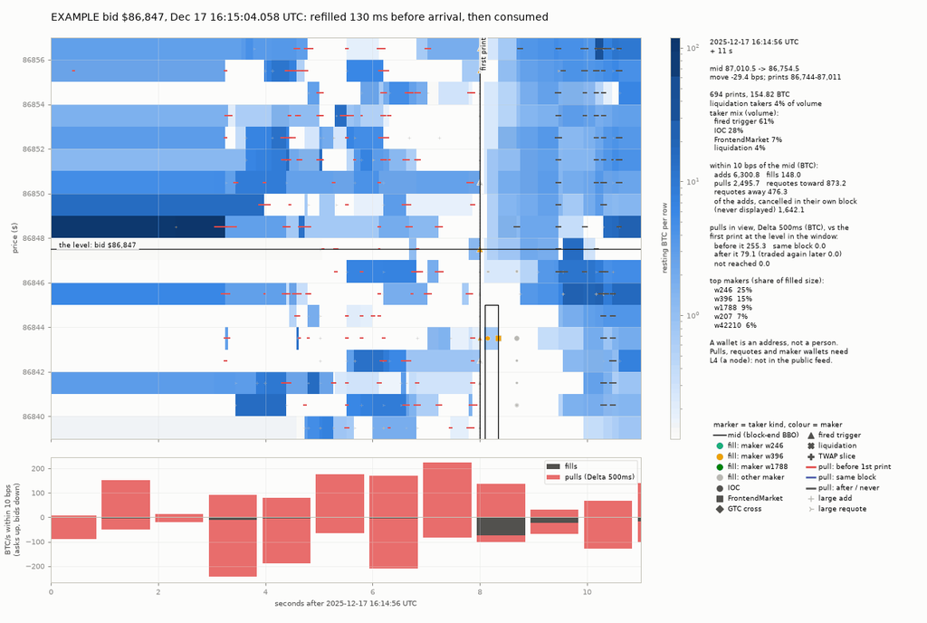

**What to look at:** the $86,847 row is thin (0.13 BTC) until a top-10 maker (w396) places 1.27 BTC there **130 ms** before a fired stop (triangle) sells into it and fills all of it. What traded was a fresh quote, not size that had been displayed.

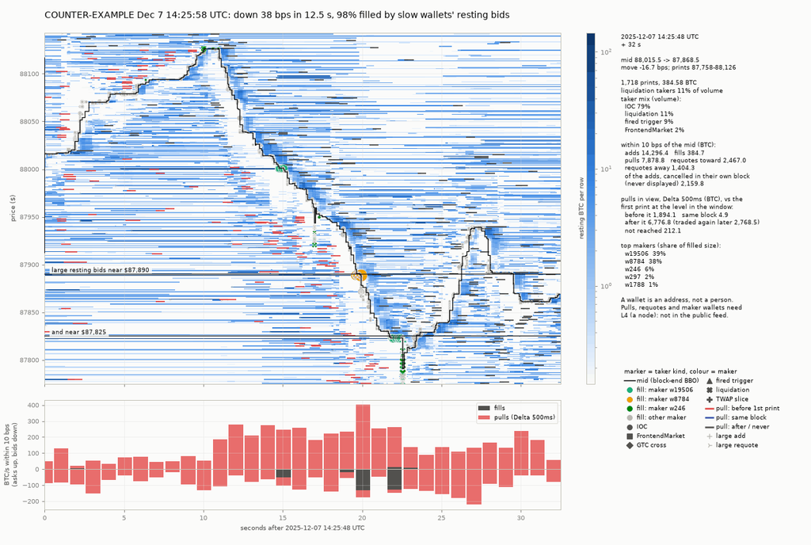

**What to look at:** two dark (large) bid rows that stay put until price arrives; the marker colours show two makers (w19506 39%, w8784 38%) absorbing 309 BTC of selling, and the mid **stalls at each of those rows**. Here the displayed size was real.

**Interpretation.** Most size a few ticks ahead belongs to HF quoters, and ~98% of it moves or leaves before price gets there. What trades is fresh quotes placed in the last seconds plus slow wallets' resting orders. **'Big size shown' is a weak promise, and 'nothing shown' does not mean nothing will trade.** The per-type fill rates are partly definitional (a wallet typed 'low activity' rarely cancels).

**Class.** Who owns a level and whether an order is fresh: **B-L4**. The maker wallet of each execution: **A**, after the print. Following ≤ 10 named wallets: **B-addr**.

```python
render_card(T("2025-12-17 16:14:56.058"), T("2025-12-17 16:15:07.058"), 86839, 86856,
            title="EXAMPLE bid $86,847, Dec 17 16:15:04.058 UTC: refilled 130 ms before arrival, then consumed",
            hlines=[(86847, "the level: bid $86,847")], vlines=[(T("2025-12-17 16:15:04.058"), "first print")],
            caption="**What to look at:** the $86,847 row is thin (0.13 BTC) until a top-10 maker (w396) "
                    "places 1.27 BTC there **130 ms** before a fired stop (triangle) sells into it and fills "
                    "all of it. What traded was a fresh quote, not size that had been displayed.")
render_card(T("2025-12-07 14:25:48.4"), T("2025-12-07 14:26:20.9"), 87775, 88142,
            title="COUNTER-EXAMPLE Dec 7 14:25:58 UTC: down 38 bps in 12.5 s, 98% filled by slow wallets' resting bids",
            hlines=[(87890, "large resting bids near $87,890"), (87825, "and near $87,825")],
            caption="**What to look at:** two dark (large) bid rows that stay put until price arrives; the "
                    "marker colours show two makers (w19506 39%, w8784 38%) absorbing 309 BTC of selling, "
                    "and the mid **stalls at each of those rows**. Here the displayed size was real.")
note("Of the size displayed 2 s before price arrived (fast, 56,933 BTC), only 8.0% [6.2–10.3] was executed "
     "(slow: 10.0%). Top-10 makers held 58% of it and 1.9% of theirs traded; other HF quoters 33% / 1.7%; "
     "~17k low-activity wallets 9% / 71% [62–78]. Of ALL fills at traversed levels (10,300 BTC), HF-type "
     "wallets supplied 60% [53–67]; 50.5% [44–56] were HF orders placed in the last 2 s. Low-activity "
     "wallets supplied 52% [40–63] of fills in down moves vs 29% [23–35] in up moves (14 of 88 moves "
     "supply half of all low-activity fills).",
     "Most size a few ticks ahead belongs to HF quoters, and ~98% of it moves or leaves before price gets "
     "there. What trades is fresh quotes placed in the last seconds plus slow wallets' resting orders. "
     "**'Big size shown' is a weak promise, and 'nothing shown' does not mean nothing will trade.** The "
     "per-type fill rates are partly definitional (a wallet typed 'low activity' rarely cancels).",
     "Who owns a level and whether an order is fresh: **B-L4**. The maker wallet of each execution: "
     "**A**, after the print. Following ≤ 10 named wallets: **B-addr**.")
```

[output not shown]

#### 1.4 (Q3) At arrival, traversed levels held far less than calm levels at the same distance, although 5 s earlier they looked ordinary

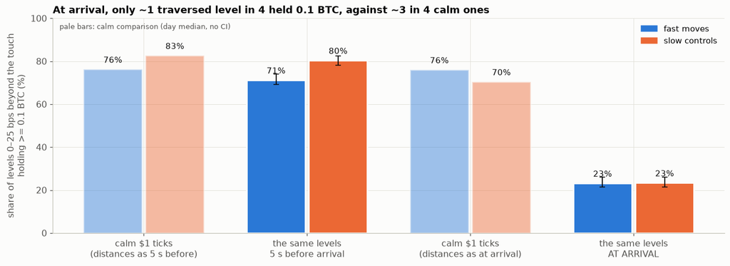

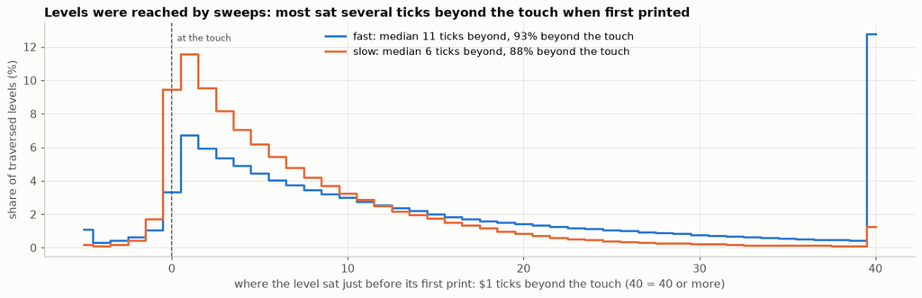

```
>= 1 BTC at arrival (fast): 9% [8–11] of levels vs 47% of calm ticks. Median sweep width: 21 (fast) and 10 (slow) levels first printed at the same instant.
```

```python
V = Q13["q3_v2"]
thr = ">= 0.1 BTC"
groups = ["calm $1 ticks\n(distances as 5 s before)", "the same levels\n5 s before arrival",
          "calm $1 ticks\n(distances as at arrival)", "the same levels\nAT ARRIVAL"]
fig, ax = plt.subplots(figsize=(12, 4.3))
x = np.arange(4)
for dx, side, col in ((-0.19, "fast", C["fast"]), (0.19, "slow", C["slow"])):
    p5, arr = V[side]["calm_match_point5s"][thr], V[side]["calm_match_arrival"][thr]
    lv5, lva = est(p5["levels"]), est(arr["levels"])
    vals = [p5["calm_day_median"], lv5[0], arr["calm_day_median"], lva[0]]
    bars = ax.bar(x + dx, np.array(vals) * 100, width=0.36, color=col, edgecolor=C["surface"], lw=2)
    for i in (0, 2):
        bars[i].set_alpha(0.45)
    for i, t in ((1, lv5), (3, lva)):
        ax.errorbar(x[i] + dx, t[0] * 100, yerr=[[100 * (t[0] - t[1])], [100 * (t[2] - t[0])]], fmt="none",
                    ecolor=C["ink"], capsize=3.5, elinewidth=1.2)
    for i, v in enumerate(vals):
        ax.text(x[i] + dx, v * 100 + 3, f"{100 * v:.0f}%", ha="center", fontsize=9.5, color=C["ink"])
ax.set_xticks(x, [esc(g) for g in groups])
ax.set_ylim(0, 100)
ax.set_ylabel("share of levels 0–25 bps beyond the touch\nholding >= 0.1 BTC (%)")
ax.legend(handles=[Patch(color=C["fast"], label="fast moves"), Patch(color=C["slow"], label="slow controls")],
          loc="upper right")
ax.text(0.01, 0.95, "pale bars: calm comparison (day median, no CI)", transform=ax.transAxes, fontsize=8.5,
        color=C["ink2"])
ax.set_title("At arrival, only ~1 traversed level in 4 held 0.1 BTC, against ~3 in 4 calm ones")
plt.show()

fig, ax = plt.subplots(figsize=(12, 3.8))
for side, col in (("fast", C["fast"]), ("slow", C["slow"])):
    h = pd.Series(V[side]["hist_ticks_beyond"], dtype=float)
    h.index = h.index.astype(int)
    h = h.sort_index()
    ax.plot(h.index, h / h.sum() * 100, drawstyle="steps-mid", color=col, lw=2,
            label=f"{side}: median {est(V[side]['ticks_beyond_median'])[0]:.0f} ticks beyond, "
                  f"{100 * est(V[side]['pos_beyond_touch'])[0]:.0f}% beyond the touch")
ax.axvline(0, color=C["ink2"], lw=1, ls="--")
ax.text(0.3, ax.get_ylim()[1] * 0.92, "at the touch", fontsize=8.5, color=C["ink2"])
ax.set_xlabel("where the level sat just before its first print: $1 ticks beyond the touch (40 = 40 or more)")
ax.set_ylabel("share of traversed levels (%)")
ax.legend(loc="upper center")
ax.set_title("Levels were reached by sweeps: most sat several ticks beyond the touch when first printed")
plt.show()
a1 = V["fast"]["calm_match_arrival"][">= 1 BTC"]
print(f">= 1 BTC at arrival (fast): {fmt(est(a1['levels']))} of levels vs {100 * a1['calm_day_median']:.0f}% "
      f"of calm ticks. Median sweep width: {est(V['fast']['sweep_width_median_levels'])[0]:.0f} (fast) and "
      f"{est(V['slow']['sweep_width_median_levels'])[0]:.0f} (slow) levels first printed at the same instant.")
```

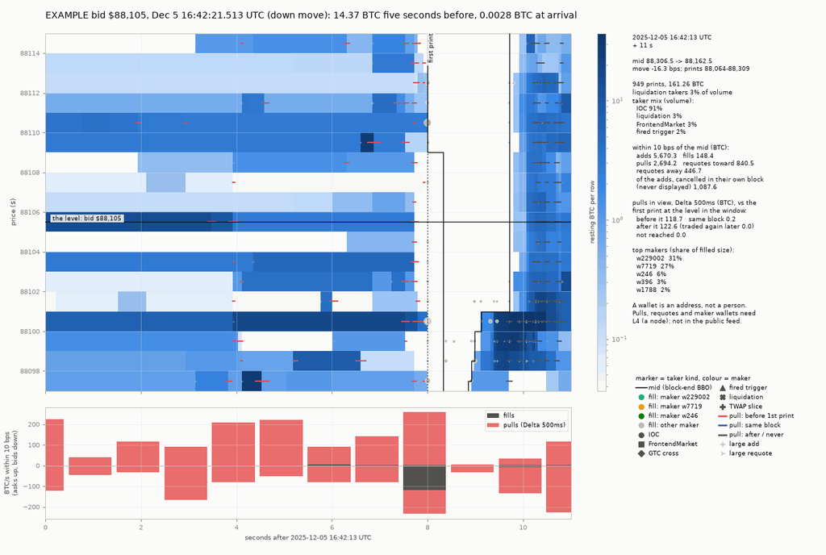

**What to look at:** the $88,105 row is dark (14.37 BTC) until w288 cancels 4.10 BTC and w1113 7.48 BTC about 4 s before (red dashes), and w246 cancels 2.79 BTC **274 ms** before; price then finds 0.0028 BTC there, in one sweep across 155 levels.

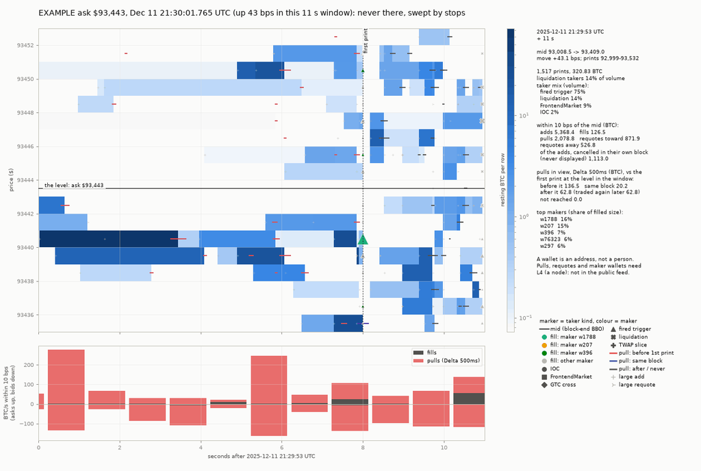

**What to look at:** the $93,443 row holds ~0.002 BTC the whole time; it is crossed in a 259-level sweep carried by fired stops (triangles, 75%) and liquidations (X, 14%). Nothing was withdrawn because nothing was there.

**Counter-example:** bid $86,847, Dec 17 16:15:04 (the card in 1.3): thin 5 s before (0.13 BTC), then **refilled 130 ms before arrival** (1.27 BTC from w396) and fully executed. The level was freshly supplied and consumed, not withdrawn.

**Observation.** Share of traversed levels 0–25 bps beyond the touch holding >= 0.1 BTC: at arrival 23% [21–26] (fast) and 23% [22–26] (slow), against 76% / 70% of calm $1 ticks at the same distances; the same levels 5 s earlier: 71% [69–74] / 80% [78–83] (calm at those distances 76% / 83%). ~1 level in 11 held >= 1 BTC at arrival, against ~1 in 2 calm. Price found 17.7% [15.2–21.5] (fast) of what the same levels held 5 s earlier. 93% (fast) / 88% (slow) of levels sat beyond the touch just before their first print (median 11 / 6 ticks); a median 21 / 10 levels were first printed at the same instant. Above dust (>= 0.001 BTC) fast and slow levels held the same size.

**Interpretation.** **Why they were thin is not identified.** A sweep runs through a stretch *because* it is thin at that moment: 'the size was withdrawn before price arrived' and 'price arrived when the stretch had emptied' are the same observation. For a trader: **the size shown a few dollars ahead in a fast market is not what a sweep will meet.**

**Class.** A shrinking $1 level: **A** within ~2 bps, net only. Pull vs fill: **B-L4**. 'About to be swept' (the traversed set): **C**. Depth at 2–25 bps: **A** only as $10-bucket totals.

```python
render_card(T("2025-12-05 16:42:13.513"), T("2025-12-05 16:42:24.513"), 88097, 88114,
            title="EXAMPLE bid $88,105, Dec 5 16:42:21.513 UTC (down move): 14.37 BTC five seconds before, 0.0028 BTC at arrival",
            hlines=[(88105, "the level: bid $88,105")], vlines=[(T("2025-12-05 16:42:21.513"), "first print")],
            caption="**What to look at:** the $88,105 row is dark (14.37 BTC) until w288 cancels 4.10 BTC and "
                    "w1113 7.48 BTC about 4 s before (red dashes), and w246 cancels 2.79 BTC **274 ms** "
                    "before; price then finds 0.0028 BTC there, in one sweep across 155 levels.")
render_card(T("2025-12-11 21:29:53.765"), T("2025-12-11 21:30:04.765"), 93435, 93452,
            title="EXAMPLE ask $93,443, Dec 11 21:30:01.765 UTC (up 43 bps in this 11 s window): never there, swept by stops",
            hlines=[(93443, "the level: ask $93,443")], vlines=[(T("2025-12-11 21:30:01.765"), "first print")],
            caption="**What to look at:** the $93,443 row holds ~0.002 BTC the whole time; it is crossed in a "
                    "259-level sweep carried by fired stops (triangles, 75%) and liquidations (X, 14%). "
                    "Nothing was withdrawn because nothing was there.")
display(Markdown("**Counter-example:** bid $86,847, Dec 17 16:15:04 (the card in 1.3): thin 5 s before "
                 "(0.13 BTC), then **refilled 130 ms before arrival** (1.27 BTC from w396) and fully "
                 "executed. The level was freshly supplied and consumed, not withdrawn."))
note("Share of traversed levels 0–25 bps beyond the touch holding >= 0.1 BTC: at arrival 23% [21–26] "
     "(fast) and 23% [22–26] (slow), against 76% / 70% of calm $1 ticks at the same distances; the same "
     "levels 5 s earlier: 71% [69–74] / 80% [78–83] (calm at those distances 76% / 83%). ~1 level in 11 held "
     ">= 1 BTC at arrival, against ~1 in 2 calm. Price found 17.7% [15.2–21.5] (fast) of what the same "
     "levels held 5 s earlier. 93% (fast) / 88% (slow) of levels sat beyond the touch just before their "
     "first print (median 11 / 6 ticks); a median 21 / 10 levels were first printed at the same instant. "
     "Above dust (>= 0.001 BTC) fast and slow levels held the same size.",
     "**Why they were thin is not identified.** A sweep runs through a stretch *because* it is thin at "
     "that moment: 'the size was withdrawn before price arrived' and 'price arrived when the stretch had "
     "emptied' are the same observation. For a trader: **the size shown a few dollars ahead in a fast "
     "market is not what a sweep will meet.**",
     "A shrinking $1 level: **A** within ~2 bps, net only. Pull vs fill: **B-L4**. 'About to be swept' "
     "(the traversed set): **C**. Depth at 2–25 bps: **A** only as $10-bucket totals.")
```

#### 1.5 (Q3) Fast moves are taken disproportionately by fired stops and liquidations

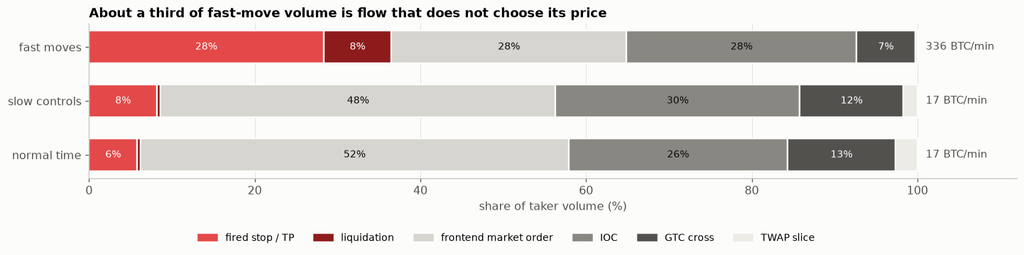

```
fired stops: fast 28% [22–40] vs normal 6% [5–7]; liquidations: fast 8% [4–13] vs normal 0.4% [0.2–0.5]
```

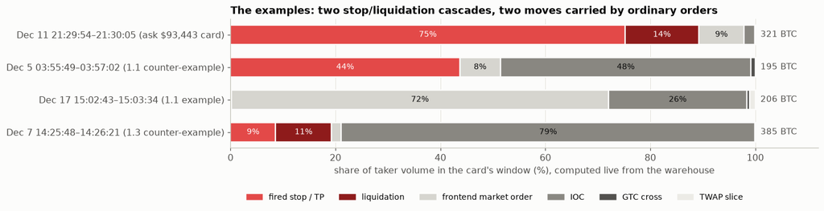

```python
TM = Q13["taker_mix"]
kinds = [("trigger", "fired stop / TP", C["pulled"]), ("liq", "liquidation", "#8e1b1b"),
         ("frontend", "frontend market order", "#d6d5cf"), ("ioc", "IOC", C["muted"]),
         ("gtc", "GTC cross", C["ink2"]), ("twap", "TWAP slice", "#ecebe6")]
regs = [("fast", "fast moves"), ("slow", "slow controls"), ("normal", "normal time")]
fig, ax = plt.subplots(figsize=(13, 3.1))
for yi, (rk, rl) in enumerate(regs):
    left = 0.0
    for k, _, col in kinds:
        v = TM[rk][k]["est"]
        ax.barh(yi, v * 100, left=left, color=col, edgecolor=C["surface"], lw=1.5, height=0.6)
        if v >= 0.04:
            ax.text(left + v * 50, yi, f"{100 * v:.0f}%", ha="center", va="center", fontsize=9,
                    color="white" if col in (C["pulled"], "#8e1b1b", C["ink2"]) else C["ink"])
        left += v * 100
    ax.text(101, yi, f"{TM[rk]['btc_per_min']:.0f} BTC/min", va="center", fontsize=9.5, color=C["ink2"])
ax.set_yticks(range(3), [r[1] for r in regs])
ax.invert_yaxis()
ax.set_xlim(0, 112)
ax.set_xticks(range(0, 101, 20))
ax.grid(axis="y", visible=False)
ax.set_xlabel("share of taker volume (%)")
ax.legend(handles=[Patch(color=c, label=n) for _, n, c in kinds], ncol=6, loc="upper center",
          bbox_to_anchor=(0.45, -0.3), fontsize=9)
ax.set_title("About a third of fast-move volume is flow that does not choose its price")
plt.show()
print(f"fired stops: fast {fmt(est(TM['fast']['trigger']))} vs normal {fmt(est(TM['normal']['trigger']))}; "
      f"liquidations: fast {fmt(est(TM['fast']['liq']))} vs normal {fmt(est(TM['normal']['liq']), d=1)}")

# the four example windows, recomputed LIVE from the warehouse's trades (tradesx)
KIND = {4: "trigger", 3: "liq", 2: "frontend", 1: "ioc", 6: "gtc", 5: "twap"}
exs = [("Dec 11 21:29:54–21:30:05 (ask $93,443 card)", "2025-12-11 21:29:53.765", "2025-12-11 21:30:04.765"),
       ("Dec 5 03:55:49–03:57:02 (1.1 counter-example)", "2025-12-05 03:55:49.0", "2025-12-05 03:57:02.4"),
       ("Dec 17 15:02:43–15:03:34 (1.1 example)", "2025-12-17 15:02:43.0", "2025-12-17 15:03:33.6"),
       ("Dec 7 14:25:48–14:26:21 (1.3 counter-example)", "2025-12-07 14:25:48.4", "2025-12-07 14:26:20.9")]
if RENDER_LIVE:
    fig, ax = plt.subplots(figsize=(13, 3.2))
    for yi, (lab, a, b) in enumerate(exs):
        tr = read_window("tradesx", ["ts", "sz", "taker_kind"], T(a), T(b))
        mix = tr.groupby("taker_kind").sz.sum() / tr.sz.sum()
        left = 0.0
        for k, _, col in kinds:
            v = float(sum(mix.get(code_, 0.0) for code_, kk in KIND.items() if kk == k))
            ax.barh(yi, v * 100, left=left, color=col, edgecolor=C["surface"], lw=1.5, height=0.6)
            if v >= 0.05:
                ax.text(left + v * 50, yi, f"{100 * v:.0f}%", ha="center", va="center", fontsize=9,
                        color="white" if col in (C["pulled"], "#8e1b1b", C["ink2"]) else C["ink"])
            left += v * 100
        ax.text(101, yi, f"{tr.sz.sum() / 1e5:,.0f} BTC", va="center", fontsize=9.5, color=C["ink2"])
    ax.set_yticks(range(len(exs)), [e[0] for e in exs])
    ax.invert_yaxis()
    ax.set_xlim(0, 112)
    ax.set_xticks(range(0, 101, 20))
    ax.grid(axis="y", visible=False)
    ax.set_xlabel("share of taker volume in the card's window (%), computed live from the warehouse")
    ax.legend(handles=[Patch(color=c, label=n) for _, n, c in kinds], ncol=6, loc="upper center",
              bbox_to_anchor=(0.45, -0.3), fontsize=9)
    ax.set_title("The examples: two stop/liquidation cascades, two moves carried by ordinary orders")
    plt.show()
```

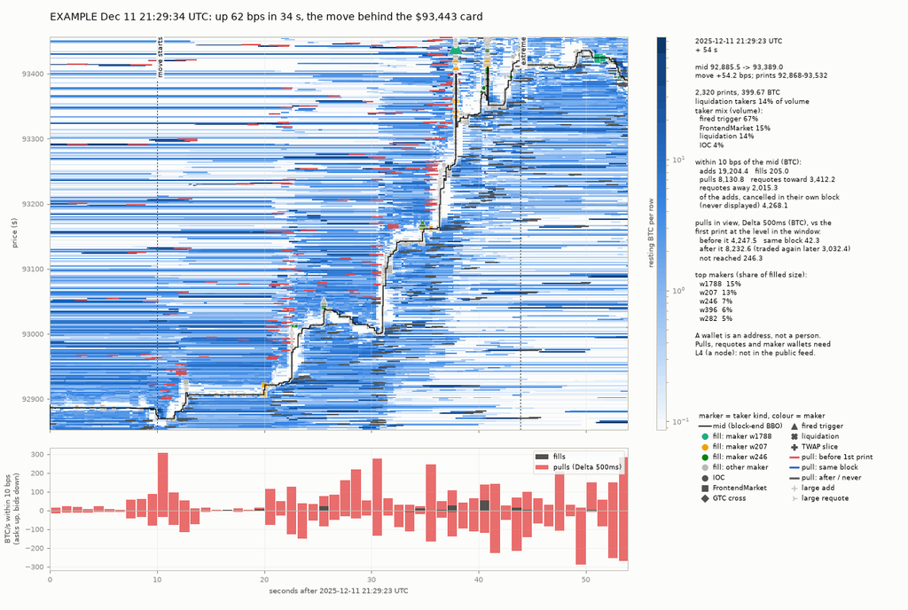

**What to look at:** the triangles (fired stops) and X's (liquidations) along the whole climb, and the empty white stretch of asks above the mid that the sweep runs through. The whole episode is 62 bps (start to extreme); the report's '43 bps' for the ask $93,443 card is the part of it inside that card's 11 s window. The counter-examples are the Dec 17 15:02:53 card in 1.1 (72% frontend market orders, stops 0.1%) and the Dec 7 14:25:58 card in 1.3 (79% IOC).

**Observation.** Fast moves traded 336 BTC/min against 17.2 in normal time (17,389 BTC over 3,102 s, 88 moves, 8 days). Fired stop/TP orders took 28% [22–40] of fast-move volume (normal time 6% [5–7]), liquidations 8% [4–13] (0.4%), frontend market orders 28% [21–34] (52%). Stops plus liquidations together: ~35%.

**Interpretation.** About a third of fast-move volume is flow that does not choose its price. With 1.1–1.4 this fits a cascade through a thin stretch; the direction of cause is not identified.

**Class.** Taker kind: **B-L4**. The public tape has no taker type and no liquidation flag; resting stops are in no public feed.

```python
t0, t1, lo, hi, r = ep_window("20251211_x20_773956")
render_card(t0, t1, lo, hi,
            title="EXAMPLE Dec 11 21:29:34 UTC: up 62 bps in 34 s, the move behind the $93,443 card",
            vlines=[(int(r.t_start), "move starts"), (int(r.t_ext), "extreme")],
            caption="**What to look at:** the triangles (fired stops) and X's (liquidations) along the whole "
                    "climb, and the empty white stretch of asks above the mid that the sweep runs through. "
                    "The whole episode is 62 bps (start to extreme); the report's '43 bps' for the ask "
                    "$93,443 card is the part of it inside that card's 11 s window. "
                    "The counter-examples are the Dec 17 15:02:53 card in 1.1 (72% frontend market orders, "
                    "stops 0.1%) and the Dec 7 14:25:58 card in 1.3 (79% IOC).")
note("Fast moves traded 336 BTC/min against 17.2 in normal time (17,389 BTC over 3,102 s, 88 moves, 8 days). "
     "Fired stop/TP orders took 28% [22–40] of fast-move volume (normal time 6% [5–7]), liquidations 8% "
     "[4–13] (0.4%), frontend market orders 28% [21–34] (52%). Stops plus liquidations together: ~35%.",
     "About a third of fast-move volume is flow that does not choose its price. With 1.1–1.4 this fits a "
     "cascade through a thin stretch; the direction of cause is not identified.",
     "Taker kind: **B-L4**. The public tape has no taker type and no liquidation flag; resting stops are in "
     "no public feed.")
```